# Predict Ratings From Reviews on Yelp

Xinran Zhang

Goal: How are reviews related to ratings? How well can we predict star rankings based on the text of reviews?

# 1 Exploratory Data Analysis (EDA)

## 1.1 Read data

```r
#data.all <- read.csv("yelp_subset.csv", as.is=TRUE) # as.is = T to keep the texts as character
data.all <- fread("data/yelp_subset.csv", stringsAsFactors = FALSE)
dim(data.all) # 100,000 documents  # length(unique(data.all$user_id))/dim(data.all)[1]
object.size(data.all) # about 92mb
```

```
## [1] 100000     10
## 94648792 bytes
```

Let’s first take a small piece of it to work through.

```r
# taking a subset of yelp data
# We could use fread with a specified nrows. We might need to shuffle the data in order to
# get a random sample.
data <- fread("data/yelp_subset.csv", nrows = 1000, stringsAsFactors = FALSE)
data <- data.all[1:1000, ] # Take a small set to work through
        # MAKE SURE: you will rerun the analyses later by
        # setting back a larger dataset.
names(data)
str(data)
#length(unique(data$user_id)) #someone wrote more than one revews
#length(unique(data$review_id)) # unique one for each review
n <- nrow(data)
levels(as.factor(data$stars))
```

```
##  [1] "user_id"      "review_id"    "text"         "votes.cool"   "business_id"
##  [6] "votes.funny"  "stars"        "date"         "type"         "votes.useful"
## Classes 'data.table' and 'data.frame':   1000 obs. of  10 variables:
##  $ user_id     : chr  "RQU7dwZTdCLfy7DQU2TYlQ" "53QaFbmZojYK0vv3RQagcw" "OVwdQ7JFDiZ3JGICBYuIHw" "te_j2wG9cTAWxXc5T6M0ig" ...
##  $ review_id   : chr  "bl8w2cxQEIFexrPQxVa_jw" "g01UnMSATfvlR83THcuYEw" "wyQi7ux65-dUKt9aWsnT3g" "JBTpvFkonR2k-6rEVwu55g" ...
##  $ text        : chr  "Super cute shop with great jewelry and gifts.  I also really love their baby stuff: bibs, clothes, toys.  It's "| __truncated__ "4 stars for potential! Large dining area with an even larger patio area. The patio area was rather impressive w"| __truncated__ "I got my Industr…
##  $ votes.cool  : int  0 1 0 0 2 2 0 0 1 0 ...
##  $ business_id : chr  "LPmFKFCwEMauGfYF0lWGnw" "IMnTtFn3c5qZ7gW0gWqPzA" "CVpKlqrjYCyjxnlkBCUK5A" "0Da5sfXzUQdiuQ1aru_8Aw" ...
##  $ votes.funny : int  0 0 0 0 1 0 0 0 0 0 ...
##  $ stars       : int  5 4 5 5 4 4 3 4 2 5 ...
##  $ date        : IDate, format: "2011-11-15" "2010-04-05" ...
##  $ type        : chr  "review" "review" "review" "review" ...
##  $ votes.useful: int  0 1 0 0 1 2 0 0 1 0 ...
##  - attr(*, ".internal.selfref")=<externalptr>
## [1] "1" "2" "3" "4" "5"
```

## 1.2 Response

We create a new response `rating` such that a review will be `good` or `1` if the original rating is at least 4 or 5. Otherwise we will code it as a `bad` or `0`. Stars or ratings are turn to a good/bad rating. We also set `rating` as a categorical variable.

```r
data$rating <- c(0)
data$rating[data$stars >= 4] <- 1
data$rating <- as.factor(data$rating)
summary(data) #str(data)
```

**Proportion of good ratings**:

```r
prop.table(table(data$rating))
```

```
##
##     0     1
## 0.398 0.602
```

Notice that $60\%$ of the reviews are good ones.

## 1.3 Date

**Does rating relate to month or day of the weeks?**

Dealing with `date` can be a challenging job. Should we treat them as continuous variables or categorical ones? This highly depends on the context and the goal of the study. In our situation it makes sense that we are interested in knowing if people tend to leave reviews over the weekend. Also, would a review left on the weekend tends to be a better one?

Let us use functions in `tidyverse` to format the dates and extract weekdays

```r
weekdays <- weekdays(as.Date(data$date)) # get weekdays for each review
months <- months(as.Date(data$date))   # get months
```

Do people tend to leave a review over weekends? (months?)

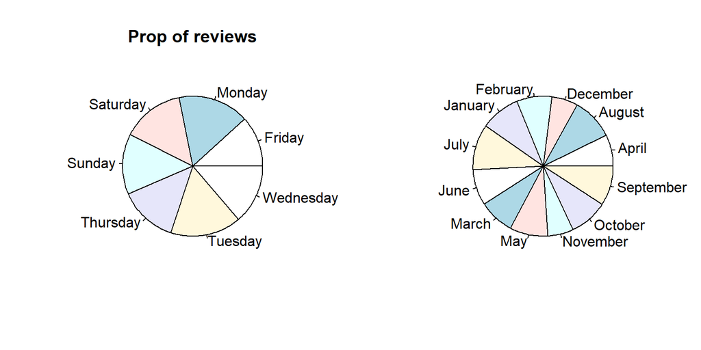

```r
par(mfrow=c(1,2))
pie(table(weekdays), main="Prop of reviews") # Pretty much evenly distributed
pie(table(months))
```

Proportion of Good reviews: Don’t really see any pattern

```r
prop.table(table(data$rating, weekdays), 2)  # prop of the columns
prop.table(table(data$rating, weekdays), 1)  # prop of the rows
```

```
##    weekdays
##        Friday    Monday  Saturday    Sunday  Thursday   Tuesday Wednesday
##   0 0.4152542 0.4049080 0.4305556 0.4000000 0.4148148 0.3190184 0.4160584
##   1 0.5847458 0.5950920 0.5694444 0.6000000 0.5851852 0.6809816 0.5839416
##    weekdays
##        Friday    Monday  Saturday    Sunday  Thursday   Tuesday Wednesday
##   0 0.1231156 0.1658291 0.1557789 0.1407035 0.1407035 0.1306533 0.1432161
##   1 0.1146179 0.1611296 0.1362126 0.1395349 0.1312292 0.1843854 0.1328904
```

# 2 Bag of words and term frequency

We will turn a text into a vector of features, each of which represents the words that are used. The specific value of the feature for a given document tells us the frequency (how many occurrences) of that word in the document.

We do this by first collect all possible words (referred to as a library or bag of all words). We will then record frequency of each word used in the review/text.

## 2.1 Word term frequency table

Let’s first take a look at the texts we have:

```r
data1.text <- data$text   # take the text out
length(data1.text)
typeof(data1.text)

print(data1.text[1:5]) # view a few documents
```

Notice number 4 and 5 are bit lengthy, which could indicate they like the place. We now extract text into word term frequency table.

### 2.1.1 Corpus

```r
mycorpus1 <- VCorpus(VectorSource(data1.text))
mycorpus1
typeof(mycorpus1)   ## It is a list
# inspect the first corpus
inspect(mycorpus1[[1]])
# or use `as.character` to extract the text
as.character(mycorpus1[[1]])
```

```
## <<VCorpus>>
## Metadata:  corpus specific: 0, document level (indexed): 0
## Content:  documents: 1000
## [1] "list"
## <<PlainTextDocument>>
## Metadata:  7
## Content:  chars: 253
##
## Super cute shop with great jewelry and gifts.  I also really love their baby stuff: bibs, clothes, toys.  It's a great place to grab a gift or browse and not have to compete with the Village chaos.
## A lot of their art and gifts are made by local artists!
## [1] "Super cute shop with great jewelry and gifts.  I also really love their baby stuff: bibs, clothes, toys.  It's a great place to grab a gift or browse and not have to compete with the Village chaos.\nA lot of their art and gifts are made by local artists!"
```

Inspect the corpus, say documents number 4 and 5.

```r
## inspect corpus 4
# as.character(mycorpus1[4])
## make it more manageable to read
# strwrap(as.character(mycorpus1[4]))
lapply(mycorpus1[4:5], as.character)  # inspect corpus 4:5
# lapply(mycorpus1[4:5], inspect)  # inspect corpus 4:5
```

### 2.1.2 Data cleaning

We transform the text into a more standard format and clean the text by removing punctuation, numbers and some common words that do not have predictive power (e.g. pronouns, prepositions, conjunctions).

```r
# Converts all words to lowercase
mycorpus_clean <- tm_map(mycorpus1, content_transformer(tolower))

# Removes common English stopwords (e.g. "with", "i")
mycorpus_clean <- tm_map(mycorpus_clean, removeWords, stopwords("english"))

# Removes any punctuation
# NOTE: This step may not be appropriate if you want to account for differences
#       on semantics depending on which sentence a word belongs to if you end up
#       using n-grams or k-skip-n-grams.
#       Instead, periods (or semicolons, etc.) can be replaced with a unique
#       token (e.g. "[PERIOD]") that retains this semantic meaning.
mycorpus_clean <- tm_map(mycorpus_clean, removePunctuation)

# Removes numbers
mycorpus_clean <- tm_map(mycorpus_clean, removeNumbers)

# Stem words
mycorpus_clean <- tm_map(mycorpus_clean, stemDocument, lazy = TRUE)

lapply(mycorpus_clean[4:5], as.character)
```

```
## $`4`
## [1] "asia bar choic go year now know everyon work now even occasion work doorman owner pretti cool peopl alway walk around make peopl feel welcom start convers live music almost everi night local band great beer select go wrong miller high life bartend friend make great drink asia suggest go soon…
##
## $`5`
## [1] "star red velvet fanat sad red velvet live standard cupcak will make come back sever choic recommend tri banana nut cupcak frost cake bit much far banana nut freakin star will probabl visit place teacak bake shop locat haha cupcak red velvet skip order star banana nut price bad price area amb…
```

### 2.1.3 Word frequency matrix

Now we transform each review into a word frequency matrix.

```r
dtm1 <- DocumentTermMatrix( mycorpus_clean )   ## library = collection of words for all documents
class(dtm1)
```

```
## [1] "DocumentTermMatrix"    "simple_triplet_matrix"
```

```r
inspect(dtm1) # typeof(dtm1)  #length(dimnames(dtm1)$Terms)
```

```
## <<DocumentTermMatrix (documents: 1000, terms: 7161)>>
## Non-/sparse entries: 51588/7109412
## Sparsity           : 99%
## Maximal term length: 73
## Weighting          : term frequency (tf)
## Sample             :
##      Terms
## Docs  food get good great just like one place realli time
##   113    3   1    3     0    2    1   2     2      2    1
##   129    1   3    3     0    1    9   6     3      3    0
##   184    0   5    7     1    1    3   2     0      2    1
##   216    0   4    0     0    0    1   0     0      0    0
##   269    3   1    2     5    3    3   0     1      2    2
##   336    3   1    3     0    2    5   2    11      0    2
##   404    0   0    0     0    2    4   2     1      0    1
##   454    0   3    4     3    3    6   5     4      4    4
##   735    3   2    0     0    3    1   2    11      2    2
##   92     5   6    6     1    8    8   4     6      4    4
```

```r
colnames(dtm1)[7150:7161] # the last a few words in the bag
# another way to get list of words
# dimnames(dtm1)$Terms[7000:7161]
dim(as.matrix(dtm1))  # we use 7161 words as predictors
```

Document 1, which is row1 in the dtm.

```r
inspect(dtm1[1,])  #Non-/sparse entries: number of non-zero entries vs. number of zero entries
```

It has 25 distinctive words; in other words, there 25 non-zero cells out of 7161 bag of words.

```r
as.matrix(dtm1[1, 1:50])  # most of the cells are 0
```

This is because review 1 only consists of 28 words after all the cleansing.

```r
sum(as.matrix(dtm1[1,]))
```

### 2.1.4 Reduce the size of the bag

We first cut the bag to only include the words appearing at least 1% of the time. This reduces the dimension of the features extracted to be analyzed.

```r
threshold <- .01*length(mycorpus_clean)   # 1% of the total documents
words.10 <- findFreqTerms(dtm1, lowfreq=threshold)  # words appearing at least among 1% of the documents
length(words.10)
words.10[580:600]
```

```r
dtm.10<- DocumentTermMatrix(mycorpus_clean, control = list(dictionary = words.10))
dim(as.matrix(dtm.10))
colnames(dtm.10)[40:50]
```

### 2.1.5 Get `DTM`

```r
# Turn texts to corpus
mycorpus1  <- VCorpus(VectorSource(data1.text))


# Control list for creating our DTM within DocumentTermMatrix
# Can tweak settings based off if you want punctuation, numbers, etc.
control_list <- list( tolower = TRUE,
                      removePunctuation = TRUE,
                      removeNumbers = TRUE,
                      stopwords = stopwords("english"),
                      stemming = TRUE)
# dtm with all terms:
dtm.10.long  <- DocumentTermMatrix(mycorpus1, control = control_list)
#inspect(dtm.10.long)

# kick out rare words
dtm.10<- removeSparseTerms(dtm.10.long, 1-.01)
inspect(dtm.10)
```

```
## <<DocumentTermMatrix (documents: 1000, terms: 950)>>
## Non-/sparse entries: 39501/910499
## Sparsity           : 96%
## Maximal term length: 12
## Weighting          : term frequency (tf)
## Sample             :
##      Terms
## Docs  food get good great just like one place realli time
##   113    3   1    3     0    2    1   2     2      2    1
##   129    1   3    3     0    1    9   6     3      3    0
##   216    0   4    0     0    0    1   0     0      0    0
##   269    3   1    2     5    3    3   0     1      2    2
##   336    3   1    3     0    2    5   2    11      0    2
##   404    0   0    0     0    2    4   2     1      0    1
##   454    0   3    4     3    3    6   5     4      4    3
##   459    3   4    2     1    2    5   3     0      1    0
##   735    3   2    0     0    3    1   2    11      2    2
##   92     5   6    6     1    8    8   4     6      4    4
```

```r
# look at the document 1 before and after cleaning
# inspect(mycorpus1[[1]])
# after cleaning
# colnames(as.matrix(dtm1[1, ]))[which(as.matrix(dtm1[1, ]) != 0)]
```

# 3 Analyses

We will use logistic regression models and LASSO to explore the relationship between `ratings` and `text`.

## 3.1 Splitting data

Let’s first read in the processed data with text being a vector.

```r
data2 <- fread("data/YELP_tm_freq.csv")  #dim(data2)
names(data2)[1:20] # notice that user_id, stars and date are in the data2
dim(data2)
data2$rating <- as.factor(data2$rating)
table(data2$rating)
#str(data2)  object.size(data2)  435Mb!!!
```

We first split data into two sets one training data and the other testing data. We use training data to build models, choose models etc and make final recommendations. We then report the performance using the testing data.

Reserve 10000 randomly chosen rows as our test data (`data2.test`) and the remaining 90000 as the training data (`data2.train`)

```r
set.seed(1)  # for the purpose of reporducibility
n <- nrow(data2)
test.index <- sample(n, 10000)
# length(test.index)
data2.test <- data2[test.index, -c(1:3)] # only keep rating and the texts
data2.train <- data2[-test.index, -c(1:3)]
dim(data2.train)
```

## 3.2 Analysis 1: LASSO

We first explore a logistic regression model using LASSO. The following R-chunk runs a LASSO model with $\alpha=.99$. The reason we take an elastic net is to enjoy the nice properties from both `LASSO` (impose sparsity) and `Ridge` (computationally stable).

```r
### or try `sparse.model.matrix()` which is much faster
y <- data2.train$rating
X1 <- sparse.model.matrix(rating~., data=data2.train)[, -1]
set.seed(2)
result.lasso <- cv.glmnet(X1, y, alpha=.99, family="binomial")
# 1.25 minutes in my MAC
plot(result.lasso)
# this this may take you long time to run, we save result.lasso
saveRDS(result.lasso, file="data/TextMining_lasso.RDS")
# result.lasso can be assigned back by
# result.lasso <- readRDS("data/TextMining_lasso.RDS")

# number of non-zero words picked up by LASSO when using lambda.1se
coef.1se <- coef(result.lasso, s="lambda.1se")
lasso.words <- coef.1se@Dimnames[[1]] [coef.1se@i][-1] # non-zero variables without intercept.
summary(lasso.words)


# or our old way
coef.1se <- coef(result.lasso, s="lambda.1se")
coef.1se <- coef.1se[which(coef.1se !=0),]
lasso.words <- rownames(as.matrix(coef.1se))[-1]
summary(lasso.words)



### cv.glmnt with the non-sparse design matrix takes much longer
# X <- as.matrix(data2.train[, -1]) # we can use as.matrix directly her
#### Be careful to run the following LASSO.
#set.seed(2)
#result.lasso <- cv.glmnet(X, y, alpha=.99, family="binomial")
# 10 minutes in my MAC
#plot(result.lasso)
```

Because of the computational burden, I have saved the LASSO results and other results into `TextMining_lasso.RDS` and `TextMining_glm.RDS`.

We resume our analyses by loading the `LASSO` results here. We extract useful variables using `lambda.1se`

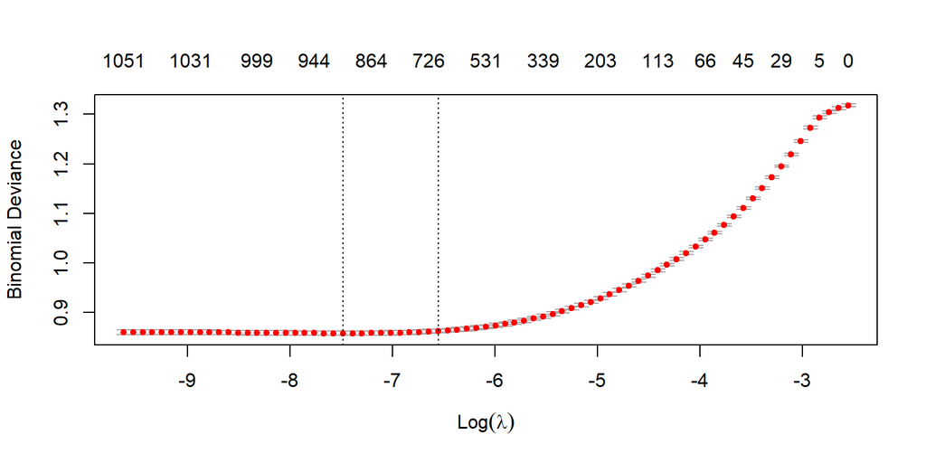

```r
result.lasso <- readRDS("data/TextMining_lasso.RDS")
plot(result.lasso)
```

```r
coef.1se <- coef(result.lasso, s="lambda.1se")
coef.1se <- coef.1se[which(coef.1se !=0),]
lasso.words <- rownames(as.matrix(coef.1se))[-1]
summary(lasso.words)
```

```
##    Length     Class      Mode
##       700 character character
```

## 3.3 Analysis 2: Relaxed LASSO

As an alternative model we will run our relaxed `LASSO`. Input variables are chosen by `LASSO` and we get a regular logistic regression model. Once again it is stored as `result.glm` in `TextMining.RData`.

```r
sel_cols <- c("rating", lasso.words)
# use all_of() to specify we would like to select variables in sel_cols
data_sub <- data2.train %>% select(all_of(sel_cols))
result.glm <- glm(rating~., family=binomial, data_sub) # takes 3.5 minutes
## glm() returns a big object with unnecessary information
# saveRDS(result.glm,
#      file = "data/TextMining_glm.RDS")

stripGlmLR = function(cm) {
  cm$y = c()
  cm$model = c()

  cm$residuals = c()
  cm$fitted.values = c()
  cm$effects = c()
  cm$qr$qr = c()
  cm$linear.predictors = c()
  cm$weights = c()
  cm$prior.weights = c()
  cm$data = c()


  cm$family$variance = c()
  cm$family$dev.resids = c()
  cm$family$aic = c()
  cm$family$validmu = c()
  cm$family$simulate = c()
  attr(cm$terms,".Environment") = c()
  attr(cm$formula,".Environment") = c()

  cm
}

result.glm.small <- stripGlmLR(result.glm)

saveRDS(result.glm.small,
     file = "data/TextMining_glm_small.RDS")
```

## 3.4 Analysis 3: Word cloud! (Sentiment analysis)

TIME TO PLOT A WORD CLOUD!! The size of the words are prop to the logistic reg coef’s

**Positive word cloud**:

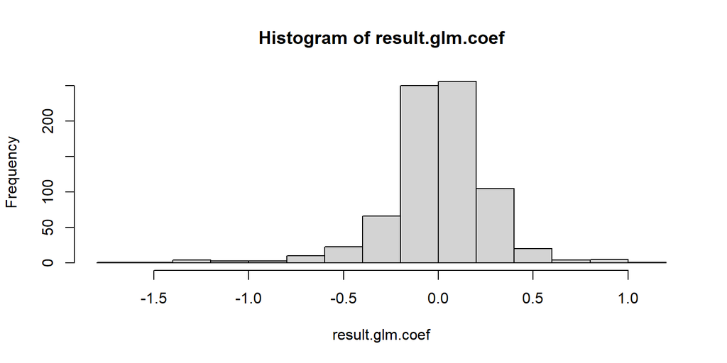

```r
result.glm <- readRDS("data/TextMining_glm_small.RDS")
result.glm.coef <- coef(result.glm)
result.glm.coef[200:250]
hist(result.glm.coef)
```

```r
# pick up the positive coef's which are positively related to the prob of being a good review
good.glm <- result.glm.coef[which(result.glm.coef > 0)]
good.glm <- good.glm[-1]  # took intercept out
names(good.glm)[1:20]  # which words are positively associated with good ratings

good.fre <- sort(good.glm, decreasing = TRUE) # sort the coef's
round(good.fre, 4)[1:20] # leading 20 positive words, amazing!
length(good.fre)  # 390 good words

# hist(as.matrix(good.fre), breaks=30, col="red")
good.word <- names(good.fre)  # good words with a decreasing order in the coeff's
```

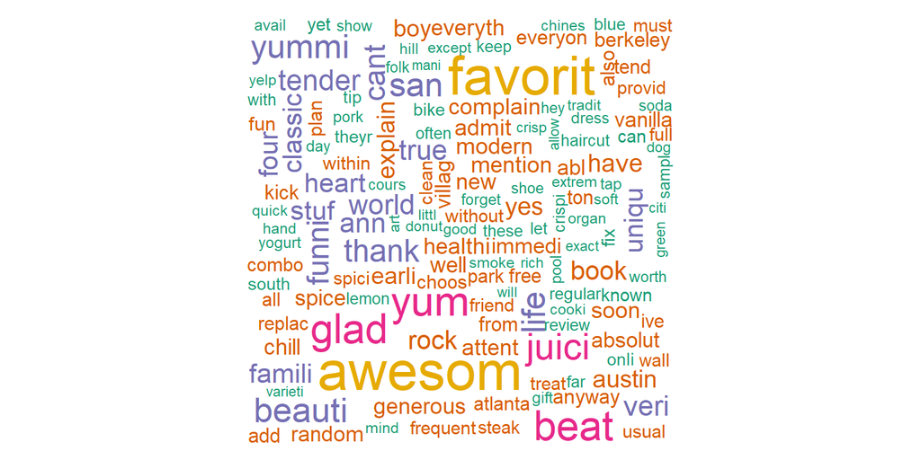

```r
cor.special <- brewer.pal(8,"Dark2")  # set up a pretty color scheme
wordcloud(good.word[1:300], good.fre[1:300],  # make a word cloud
          colors=cor.special, ordered.colors=F)
```

**Negative word cloud**:

```r
bad.glm <- result.glm.coef[which(result.glm.coef < 0)]
# names(bad.glm)[1:50]

cor.special <- brewer.pal(6,"Dark2")
bad.fre <- sort(-bad.glm, decreasing = TRUE)
round(bad.fre, 4)[1:40]
```

```
##      worst    mediocr       rude    terribl    horribl     overpr      bland
##     1.6418     1.5544     1.3602     1.2859     1.2527     1.2035     1.1885
##       wors    alright   unfortun      gross       wast       poor       lack
##     1.0732     1.0004     0.9171     0.9076     0.8165     0.7503     0.7283
##       okay     averag   elsewher      sorri     decent       noth       mess
##     0.7174     0.7069     0.7028     0.6808     0.6464     0.6372     0.6145
## disappoint        sad      dirti        dri       slow      howev       paid
##     0.6145     0.5846     0.5746     0.5734     0.5509     0.5461     0.5296
##    attitud       bare       suck      salti     suppos        not      forev
##     0.5246     0.5123     0.5053     0.5027     0.4926     0.4887     0.4770
##        whi   somewher      guess       fine     bother
##     0.4644     0.4583     0.4462     0.4441     0.4424
```

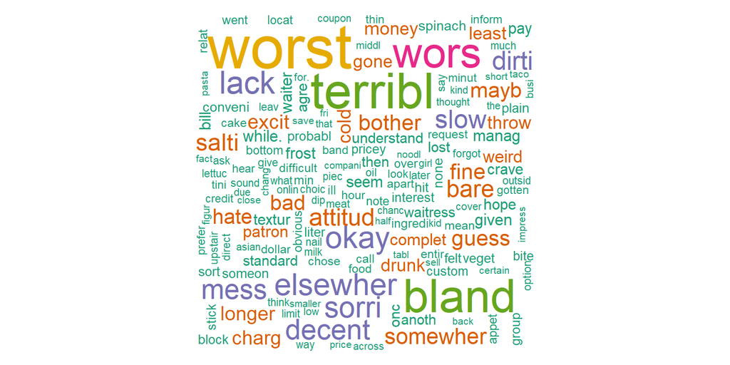

```r
# hist(as.matrix(bad.fre), breaks=30, col="green")
bad.word <- names(bad.fre)
wordcloud(bad.word[1:300], bad.fre[1:300],
          color=cor.special, ordered.colors=F)
```

**Put two clouds together**:

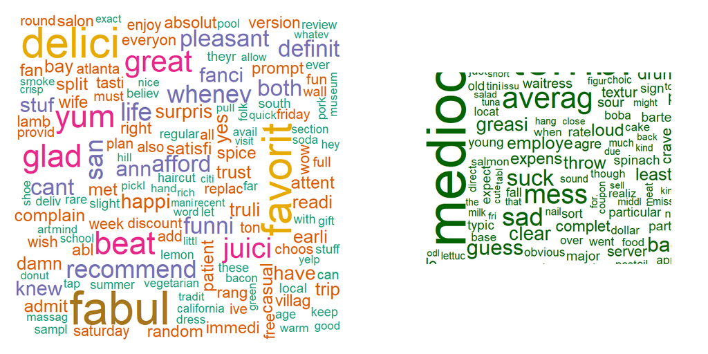

```r
par(mfrow=c(1,2))
cor.special <- brewer.pal(8,"Dark2")
wordcloud(good.word[1:300], good.fre[1:300],
          colors=cor.special, ordered.colors=F)
wordcloud(bad.word[1:300], bad.fre[1:300],
          color="darkgreen", ordered.colors=F)
```

```r
par(mfrow=c(1,1))
```

## 3.5 Analysis 4: Predictions

We have obtained two sets of models one from `LASSO` the other from `relaxed LASSO`. To compare the performance as classifiers we will evaluate their `mis-classification error` and/or `ROC` curves using `testing data`.

### 3.5.1 1) How does glm do in terms of classification?

Use the testing data we get mis-classification errors for one rule: majority vote.

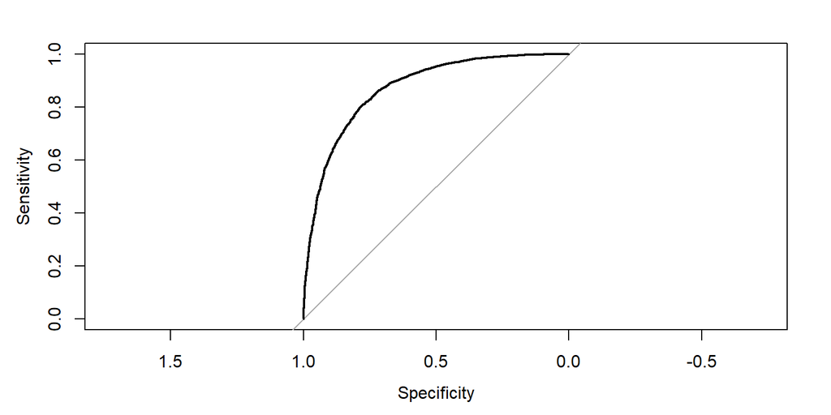

```
## [1] 0.1931
##
## Call:
## roc.default(response = data2.test$rating, predictor = predict.glm,     plot = T)
##
## Data: predict.glm in 3739 controls (data2.test$rating 0) < 6261 cases (data2.test$rating 1).
## Area under the curve: 0.8708
```

```r
predict.glm <- predict(result.glm, data2.test, type = "response")
class.glm <- ifelse(predict.glm > .5, "1", "0")
# length(class.glm)

testerror.glm <- mean(data2.test$rating != class.glm)
testerror.glm   # mis classification error is 0.19

pROC::roc(data2.test$rating, predict.glm, plot=T) # AUC=.87!!!!
```

### 3.5.2 2) LASSO model using `lambda.1se`

Once again we evaluate the testing performance of `LASSO` solution.

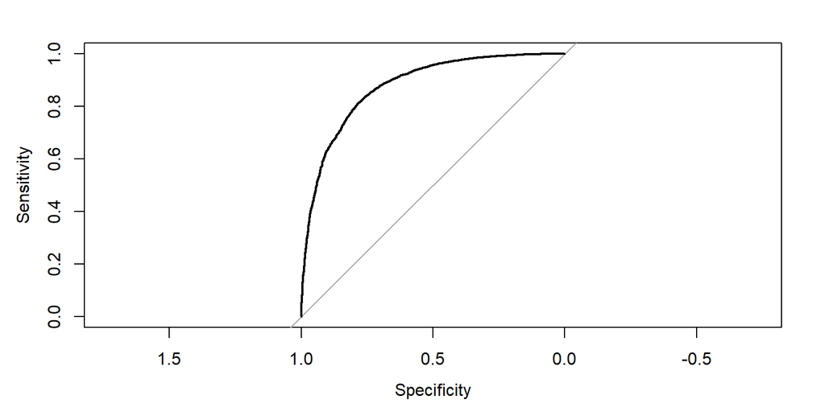

```
## [1] 0.1931
##
## Call:
## roc.default(response = data2.test$rating, predictor = predict.lasso.p,     plot = TRUE)
##
## Data: predict.lasso.p in 3739 controls (data2.test$rating 0) < 6261 cases (data2.test$rating 1).
## Area under the curve: 0.8762
```

```r
predict.lasso.p <- predict(result.lasso, as.matrix(data2.test[, -1]), type = "response", s="lambda.1se")
  # output lasso estimates of prob's
predict.lasso <- predict(result.lasso, as.matrix(data2.test[, -1]), type = "class", s="lambda.1se")
  # output majority vote labels

# LASSO testing errors
mean(data2.test$rating != predict.lasso)   # .19

# ROC curve for LASSO estimates

pROC::roc(data2.test$rating, predict.lasso.p, plot=TRUE)
```

Comparing the two predictions through testing errors/ROC we do not see much of the difference. We could use either final models for the purpose of the prediction.